# Final_estadistica_IMF_AnalisisDatos_Rdouglas

Richard Douglas Grijalba

2024-04-07

#### Estadistica para Ciencia de Datos

#### IMF Master en Data Science

#### Estudiante : Richard Douglas Grijalba

### Caso práctico final

Este es el último caso práctico de este módulo. Para realizarlo, ha de escogerse una BBDD para realizar una exploración estadística propia de un científico de datos. Para ello, se pueden seguir los siguientes pasos para desarrollar el proyecto:

#### PASO UNO

Definir un solo objetivo para el estudio con una BBDD. En este paso, se va a definir un objetivo de estudio (es muy importante que solo sea uno). Se definirá siguiendo estos puntos:

**1.1. ¿Qué problema se quiere solucionar con estos datos?**

En este dataset que corresponde a la informacion del desempeño academico de un grupo de estudiantes, se busca determinar la influencia de ciertos factores sobre sus resultados academicos.

**1.2. ¿Qué significan las variables?**

**Descripcion del Dataset** Este corresponde a un dataset de los resultados academicos de un grupo estudiantil, por lo que tendremos informacion de una poblacion en la que se busca determinar iertos resultados y cuales factores inflyen sobre estos. este dataset puede ser encontrado en www.kaggle.com / Math Students **Caracteriscticas** Características o columnas incluidas en este dataset: Ese conjunto de datos contenga una variedad de características incluye:

- Escuela : (binaria: ‘GP’ - Gabriel Pereira or ‘MS’ - Mousinho da Silveira)
- Edad del estudiante (numérico: de 15 a 22)
- Género/ sexo (binario: “F” - femenino o “M” - masculino)
- Dirección (binario: “U” - urbano o “R” - rural)
- Famsize (tamaño de la familia) (binario: “LE3” - menor o igual a 3 o “GT3” - mayor que 3)
- Pstatus (estado de convivencia de los padres) (“T” - viviendo juntos o “A” - separados)
- Medu (nivel educativo de la madre) (numérico: 0 - ninguna, 1 - educación primaria (4º grado), 2 - de 5º a 9º grado, 3 - educación secundaria o 4 - educación superior)
- Fedu (nivel educativo del padre) (numérico: 0 - ninguna, 1 - educación primaria (4º grado), 2 - de 5º a 9º grado, 3 - educación secundaria o 4 - educación superior)
- Mjob (trabajo de la madre) (nominal: “profesor(a)”, relacionado con la “salud”, “servicios” civiles (por ejemplo, administrativo o policial), “en_casa” u “otro”)
- Fjob (trabajo del padre) (nominal: “profesor(a)”, relacionado con la “salud”, “servicios” civiles (por ejemplo, administrativo o policial), “en_casa” u “otro”)
- Reason (razón para elegir la escuela)
- Traveltime (tiempo de viaje a la escuela) (numérico: 1 - <15 min., 2 - de 15 a 30 min., 3 - de 30 min. a 1 hora, o 4 - >1 hora)
- Studytime (tiempo de estudio semanal) (numérico: 1 - <2 horas, 2 - de 2 a 5 horas, 3 - de 5 a 10 horas, o 4 - >10 horas)
- Failures (número de fallos en cursos anteriores)
- Schoolsup (apoyo educativo adicional)
- Famrel (calidad de las relaciones familiares)
- Freetime (tiempo libre después de la escuela)
- Goout (frecuencia de salir con amigos)
- Dalc (consumo de alcohol en días laborales)
- Walc (consumo de alcohol en fines de semana)
- Health (estado de salud actual)
- Absences (número de ausencias escolares) (numérico: de 0 a 93)
- G1, G2, G3 (notas en diferentes momentos del año escolar)

**1.3. ¿Qué tipo de variables hay?**

tenemos variables numericas, binomiales (si o no) y del tipo string o categoricas con varias opciones.

#### Categóricas:

- sexo
- dirección
- tamaño de la familia
- estado de convivencia de los padres
- trabajo de la madre
- trabajo del padre
- razón para elegir esta escuela
- tutor
- apoyo escolar
- apoyo familiar
- actividades extracurriculares
- quiere cursar educación superior
- internet
- relacion/romántico

#### Numéricas:

- edad
- Medu (educación de la madre)
- Fedu (educación del padre)
- tiempo de viaje
- tiempo de estudio
- fracasos
- relación familiar
- tiempo libre salir
- consumo de alcohol en días laborables
- consumo de alcohol en fines de semana
- salud
- ausencias las cuales se decriben estadisticamente mas adelante, por medio de la exploracion de los datos

**1.4.Definir un objetivo que ayude a solucionar el problema.**

Obtener una relacion entre los factores de exito de los estudiantes.

En este caso se determina que cada estudiante tiene las mismas oportunidades para obtner un grado academico o desarrollarse, sin embargo por medio de los resultados estadisticos se buscara determinar que factor puede favorecer a los estudiantes un mejor desempeño academico.

Tenemos estudiantes mujeres y hombres, Puede este factor influir en los resultados? *Se realizara un grafico y tabla por genero.

**Los Estudiantes que dedican mas tiempo de estudio tienen menos perdidas de materias, se aussentan igual que aquellos que dedican menos tiempo de horas de estudio?**

#### PASO DOS

**2.Exploración de datos:**

**2.1. Crear los gráficos más apropiados.**

**2.2. Interpretar los gráficos.**

**2.3. Encontrar los primeros indicios y sacar las preconclusiones.**

**2.4. Listar por orden de importancia los indicios que han desvelado los gráficos.**

.

**llamado / carga de las librerias para el desarrollo de este caso**

```r
## **se conoce el entorno de trabajo**
getwd()
```

```
## [1] "C:/Users/Rdouglas/OneDrive/1-Master Ciencia Datos/1-Materias/5-Modulo - estadistica/asignaciones/asignacion final"
```

```r
## **se cargan las librerias para el desarrollo del caso**
library(dplyr)
library(openintro)
```

```r
## visualizacin de graficos

library(ggplot2)
## lirberia para graficos
library(plotly)
## esta libreria : manipulacion, visualizacion de datos
library(tidyverse)
## Esta libreria para crear tablas cruzadas
library(crosstable)
library(corrplot)
library(gmodels)
library(ggmosaic)
library(corrplot)

library(tidyr)

library(pivottabler)
```

#### **Exploración de datos:**

**Se procede a llamar el datset previamente descrito, en este caso se realiza la exploracion de los datos de una forma estaditica**

```r
df1 <-read.csv("student-mat.csv", sep=';', stringsAsFactors=T)
```

**Breve descripcion del dataset**

```r
summary(df1)
```

```
##  school   sex          age       address famsize   Pstatus      Medu
##  GP:349   F:208   Min.   :15.0   R: 88   GT3:281   A: 41   Min.   :0.000
##  MS: 46   M:187   1st Qu.:16.0   U:307   LE3:114   T:354   1st Qu.:2.000
##                   Median :17.0                             Median :3.000
##                   Mean   :16.7                             Mean   :2.749
##                   3rd Qu.:18.0                             3rd Qu.:4.000
##                   Max.   :22.0                             Max.   :4.000
##       Fedu             Mjob           Fjob            reason      guardian
##  Min.   :0.000   at_home : 59   at_home : 20   course    :145   father: 90
##  1st Qu.:2.000   health  : 34   health  : 18   home      :109   mother:273
##  Median :2.000   other   :141   other   :217   other     : 36   other : 32
##  Mean   :2.522   services:103   services:111   reputation:105
##  3rd Qu.:3.000   teacher : 58   teacher : 29
##  Max.   :4.000
##    traveltime      studytime        failures      schoolsup famsup     paid
##  Min.   :1.000   Min.   :1.000   Min.   :0.0000   no :344   no :153   no :214
##  1st Qu.:1.000   1st Qu.:1.000   1st Qu.:0.0000   yes: 51   yes:242   yes:181
##  Median :1.000   Median :2.000   Median :0.0000
##  Mean   :1.448   Mean   :2.035   Mean   :0.3342
##  3rd Qu.:2.000   3rd Qu.:2.000   3rd Qu.:0.0000
##  Max.   :4.000   Max.   :4.000   Max.   :3.0000
##  activities nursery   higher    internet  romantic      famrel
##  no :194    no : 81   no : 20   no : 66   no :263   Min.   :1.000
##  yes:201    yes:314   yes:375   yes:329   yes:132   1st Qu.:4.000
##                                                     Median :4.000
##                                                     Mean   :3.944
##                                                     3rd Qu.:5.000
##                                                     Max.   :5.000
##     freetime         goout            Dalc            Walc
##  Min.   :1.000   Min.   :1.000   Min.   :1.000   Min.   :1.000
##  1st Qu.:3.000   1st Qu.:2.000   1st Qu.:1.000   1st Qu.:1.000
##  Median :3.000   Median :3.000   Median :1.000   Median :2.000
##  Mean   :3.235   Mean   :3.109   Mean   :1.481   Mean   :2.291
##  3rd Qu.:4.000   3rd Qu.:4.000   3rd Qu.:2.000   3rd Qu.:3.000
##  Max.   :5.000   Max.   :5.000   Max.   :5.000   Max.   :5.000
##      health         absences            G1              G2
##  Min.   :1.000   Min.   : 0.000   Min.   : 3.00   Min.   : 0.00
##  1st Qu.:3.000   1st Qu.: 0.000   1st Qu.: 8.00   1st Qu.: 9.00
##  Median :4.000   Median : 4.000   Median :11.00   Median :11.00
##  Mean   :3.554   Mean   : 5.709   Mean   :10.91   Mean   :10.71
##  3rd Qu.:5.000   3rd Qu.: 8.000   3rd Qu.:13.00   3rd Qu.:13.00
##  Max.   :5.000   Max.   :75.000   Max.   :19.00   Max.   :19.00
##        G3
##  Min.   : 0.00
##  1st Qu.: 8.00
##  Median :11.00
##  Mean   :10.42
##  3rd Qu.:14.00
##  Max.   :20.00
```

```r
glimpse(df1)
```

```
## Rows: 395
## Columns: 33
## $ school     <fct> GP, GP, GP, GP, GP, GP, GP, GP, GP, GP, GP, GP, GP, GP, GP,…
## $ sex        <fct> F, F, F, F, F, M, M, F, M, M, F, F, M, M, M, F, F, F, M, M,…
## $ age        <int> 18, 17, 15, 15, 16, 16, 16, 17, 15, 15, 15, 15, 15, 15, 15,…
## $ address    <fct> U, U, U, U, U, U, U, U, U, U, U, U, U, U, U, U, U, U, U, U,…
## $ famsize    <fct> GT3, GT3, LE3, GT3, GT3, LE3, LE3, GT3, LE3, GT3, GT3, GT3,…
## $ Pstatus    <fct> A, T, T, T, T, T, T, A, A, T, T, T, T, T, A, T, T, T, T, T,…
## $ Medu       <int> 4, 1, 1, 4, 3, 4, 2, 4, 3, 3, 4, 2, 4, 4, 2, 4, 4, 3, 3, 4,…
## $ Fedu       <int> 4, 1, 1, 2, 3, 3, 2, 4, 2, 4, 4, 1, 4, 3, 2, 4, 4, 3, 2, 3,…
## $ Mjob       <fct> at_home, at_home, at_home, health, other, services, other, …
## $ Fjob       <fct> teacher, other, other, services, other, other, other, teach…
## $ reason     <fct> course, course, other, home, home, reputation, home, home, …
## $ guardian   <fct> mother, father, mother, mother, father, mother, mother, mot…
## $ traveltime <int> 2, 1, 1, 1, 1, 1, 1, 2, 1, 1, 1, 3, 1, 2, 1, 1, 1, 3, 1, 1,…
```

[output cut: 20 more lines]

**Exploracion general de los datos y dataset**

```r
# Mostrar el número de columnas en df1
num_columnas <- ncol(df1)
print(paste("Número de columnas:", num_columnas))
```

```
## [1] "Número de columnas: 33"
```

```r
# Mostar el número de filas en df1
num_filas <- nrow(df1)
print(paste("Número de filas:", num_filas))
```

```
## [1] "Número de filas: 395"
```

```r
# Mostrar las primeras 10 filas de df1
head_10 <- head(df1, 10)
print(head_10)
```

```
##    school sex age address famsize Pstatus Medu Fedu     Mjob     Fjob
## 1      GP   F  18       U     GT3       A    4    4  at_home  teacher
## 2      GP   F  17       U     GT3       T    1    1  at_home    other
## 3      GP   F  15       U     LE3       T    1    1  at_home    other
## 4      GP   F  15       U     GT3       T    4    2   health services
## 5      GP   F  16       U     GT3       T    3    3    other    other
## 6      GP   M  16       U     LE3       T    4    3 services    other
## 7      GP   M  16       U     LE3       T    2    2    other    other
## 8      GP   F  17       U     GT3       A    4    4    other  teacher
## 9      GP   M  15       U     LE3       A    3    2 services    other
## 10     GP   M  15       U     GT3       T    3    4    other    other
##        reason guardian traveltime studytime failures schoolsup famsup paid
## 1      course   mother          2         2        0       yes     no   no
## 2      course   father          1         2        0        no    yes   no
## 3       other   mother          1         2        3       yes     no  yes
```

[output cut: 29 more lines]

```r
# Ahora vamos a ver la estructura del dataframe
str(df1)
```

```
## 'data.frame':    395 obs. of  33 variables:
##  $ school    : Factor w/ 2 levels "GP","MS": 1 1 1 1 1 1 1 1 1 1 ...
##  $ sex       : Factor w/ 2 levels "F","M": 1 1 1 1 1 2 2 1 2 2 ...
##  $ age       : int  18 17 15 15 16 16 16 17 15 15 ...
##  $ address   : Factor w/ 2 levels "R","U": 2 2 2 2 2 2 2 2 2 2 ...
##  $ famsize   : Factor w/ 2 levels "GT3","LE3": 1 1 2 1 1 2 2 1 2 1 ...
##  $ Pstatus   : Factor w/ 2 levels "A","T": 1 2 2 2 2 2 2 1 1 2 ...
##  $ Medu      : int  4 1 1 4 3 4 2 4 3 3 ...
##  $ Fedu      : int  4 1 1 2 3 3 2 4 2 4 ...
##  $ Mjob      : Factor w/ 5 levels "at_home","health",..: 1 1 1 2 3 4 3 3 4 3 ...
##  $ Fjob      : Factor w/ 5 levels "at_home","health",..: 5 3 3 4 3 3 3 5 3 3 ...
##  $ reason    : Factor w/ 4 levels "course","home",..: 1 1 3 2 2 4 2 2 2 2 ...
##  $ guardian  : Factor w/ 3 levels "father","mother",..: 2 1 2 2 1 2 2 2 2 2 ...
##  $ traveltime: int  2 1 1 1 1 1 1 2 1 1 ...
##  $ studytime : int  2 2 2 3 2 2 2 2 2 2 ...
```

[output cut: 19 more lines]

```r
# Contar los valores nulos en cada columna del dataframe
num_valores_nulos <- colSums(is.na(df1))

# Imprimir el resultado
print(num_valores_nulos)
```

```
##     school        sex        age    address    famsize    Pstatus       Medu
##          0          0          0          0          0          0          0
##       Fedu       Mjob       Fjob     reason   guardian traveltime  studytime
##          0          0          0          0          0          0          0
##   failures  schoolsup     famsup       paid activities    nursery     higher
##          0          0          0          0          0          0          0
##   internet   romantic     famrel   freetime      goout       Dalc       Walc
##          0          0          0          0          0          0          0
##     health   absences         G1         G2         G3
##          0          0          0          0          0
```

```r
## Calculo de Rango Interquartilico en Variables Edad y Ausencias
## revision de las variables
summary(df1$age)
```

```
##    Min. 1st Qu.  Median    Mean 3rd Qu.    Max.
##    15.0    16.0    17.0    16.7    18.0    22.0
```

```r
#rango intercuartil
iqr <- IQR(df1$age)
print(paste("Rango intercuartilico de Edad es de:",iqr))
```

```
## [1] "Rango intercuartilico de Edad es de: 2"
```

```r
# revision de las variables
summary(df1$absences)
```

```
##    Min. 1st Qu.  Median    Mean 3rd Qu.    Max.
##   0.000   0.000   4.000   5.709   8.000  75.000
```

```r
#rango intercuartil
iqr1 <- IQR(df1$absences)
print(paste("Rango intercuartilico de ausencias es de:",iqr1))
```

```
## [1] "Rango intercuartilico de ausencias es de: 8"
```

```r
# revision de las variables
summary(df1$studytime)
```

```
##    Min. 1st Qu.  Median    Mean 3rd Qu.    Max.
##   1.000   1.000   2.000   2.035   2.000   4.000
```

```r
#rango intercuartil
iqr2 <- IQR(df1$studytime)
print(paste("Rango intercuartilico de Tiempo de Estudio es de:",iqr2))
```

```
## [1] "Rango intercuartilico de Tiempo de Estudio es de: 1"
```

```r
# revision de las variables
CrossTable(df1$age)
```

```
##
##
##    Cell Contents
## |-------------------------|
## |                       N |
## |         N / Table Total |
## |-------------------------|
##
##
## Total Observations in Table:  395
##
##
##           |        15 |        16 |        17 |        18 |        19 |
##           |-----------|-----------|-----------|-----------|-----------|
##           |        82 |       104 |        98 |        82 |        24 |
##           |     0.208 |     0.263 |     0.248 |     0.208 |     0.061 |
##           |-----------|-----------|-----------|-----------|-----------|
##
##
##           |        20 |        21 |        22 |
##           |-----------|-----------|-----------|
##           |         3 |         1 |         1 |
##           |     0.008 |     0.003 |     0.003 |
##           |-----------|-----------|-----------|
##
##
##
##
```

```r
# revision de las variables
summary(df1$sex)
```

```
##   F   M
## 208 187
```

```r
# revision de las variables
CrossTable(df1$sex)
```

```
##
##
##    Cell Contents
## |-------------------------|
## |                       N |
## |         N / Table Total |
## |-------------------------|
##
##
## Total Observations in Table:  395
##
##
##           |         F |         M |
##           |-----------|-----------|
##           |       208 |       187 |
##           |     0.527 |     0.473 |
##           |-----------|-----------|
##
##
##
##
```

```r
# revision de las variables
summary(df1$sex)
```

```
##   F   M
## 208 187
```

```r
# revision de las variables
# Crear tabla resumen
tabla_resumen <- table(df1$age, df1$sex)

# Mostrar la tabla resumen
print(tabla_resumen)
```

```
##
##       F  M
##   15 38 44
##   16 54 50
##   17 58 40
##   18 43 39
##   19 14 10
##   20  1  2
##   21  0  1
##   22  0  1
```

```r
# revision de las variables
# Crear tabla resumen
tabla_resumen1 <- table(df1$school, df1$sex)

# Mostrar la tabla resumen
print(tabla_resumen1)
```

```
##
##        F   M
##   GP 183 166
##   MS  25  21
```

```r
# revision de las variables
df1_summarized <- df1%>%
  group_by(sex, age) %>%
  summarise(absences_sum = sum(absences)) %>%
  ungroup()
```

[output not shown]

```r
# A continuación, completamos los valores faltantes con 0
df1_complete <- df1_summarized %>%
  complete(sex, age, fill = list(absences_sum = 0))

# Por último, utilizamos pivot_wider() para dar formato de tabla pivote
tabla_pivote1 <- df1_complete %>%
  pivot_wider(names_from = age, values_from = absences_sum)

# Mostrar la tabla pivote
print(tabla_pivote1)
```

```
## # A tibble: 2 × 9
##   sex    `15`  `16`  `17`  `18`  `19`  `20`  `21`  `22`
##   <fct> <int> <int> <int> <int> <int> <int> <int> <int>
## 1 F       148   318   401   261   161     4     0     0
## 2 M       126   249   232   235    90    11     3    16
```

**Tabla Representa la Cantidad de Estudiantes Segun Edades**

```r
## esta tabla se crea con a libreria (pivottabler)
qhpvt(df1, "sex", "age", "n()")
```

[interactive chart not shown]

```r
## esta tabla se crea con a libreria (pivottabler)
qhpvt(df1, "age", "absences", "n()")
```

[interactive chart not shown]

#### **2.1. Crear los gráficos más apropiados.**

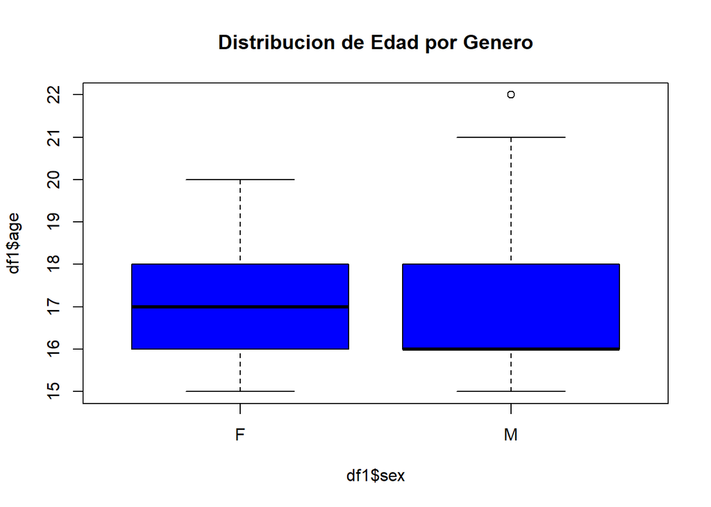

```r
boxplot(df1$age ~ df1$sex, col = "blue",
main = "Distribucion de Edad por Genero")
```

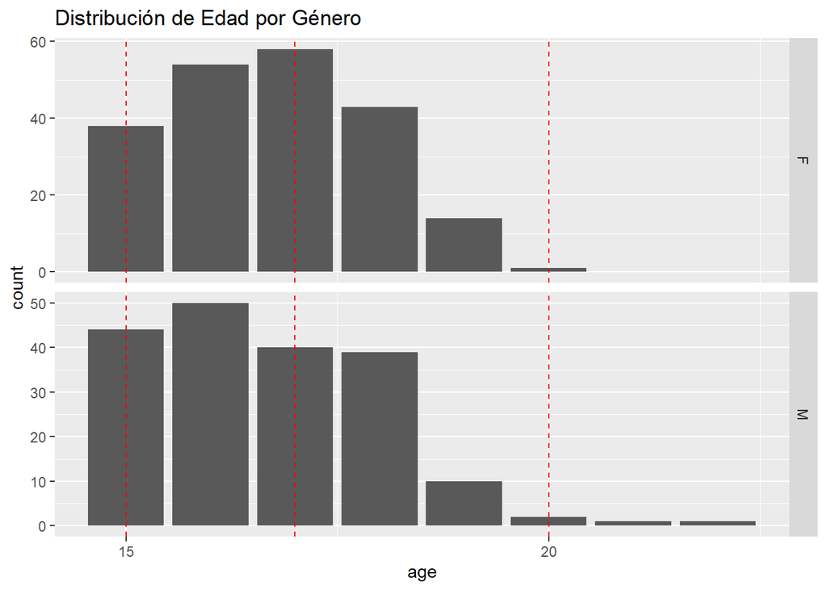

```r
df1 %>%
  ggplot() +
  aes(x = age) +
  geom_bar() +
  geom_vline(xintercept = c(15,17, 20),
             col = "red",
             linetype = "dashed") +
  facet_grid(sex ~ .,
             scales = "free_y") +
  scale_x_continuous(breaks = seq(0, 100, 5)) +
  labs(title = "Distribución de Edad por Género")
```

```r
table(df1$address)
```

```
##
##   R   U
##  88 307
```

```r
tabla_resumen <- table(df1$address, df1$sex)

# Mostrar la tabla resumen
print(tabla_resumen)
```

```
##
##       F   M
##   R  44  44
##   U 164 143
```

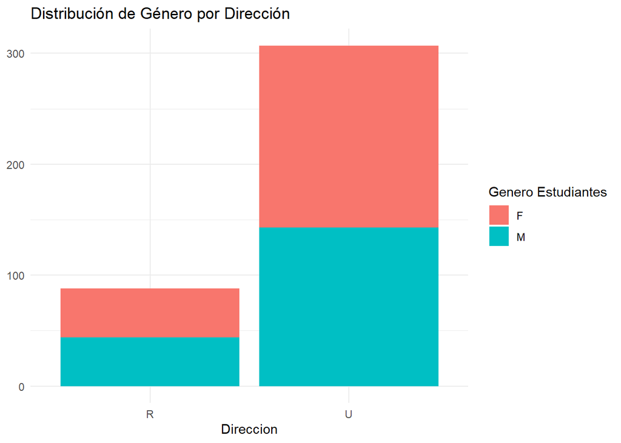

```r
df1 %>%
  ggplot() +
  geom_bar(aes(x = address, fill = sex)) +
  xlab("Direccion") +
  ylab(NULL) +
  labs(fill = "Genero Estudiantes") +
  labs(title = "Distribución de Género por Dirección") +
  theme_minimal()
```

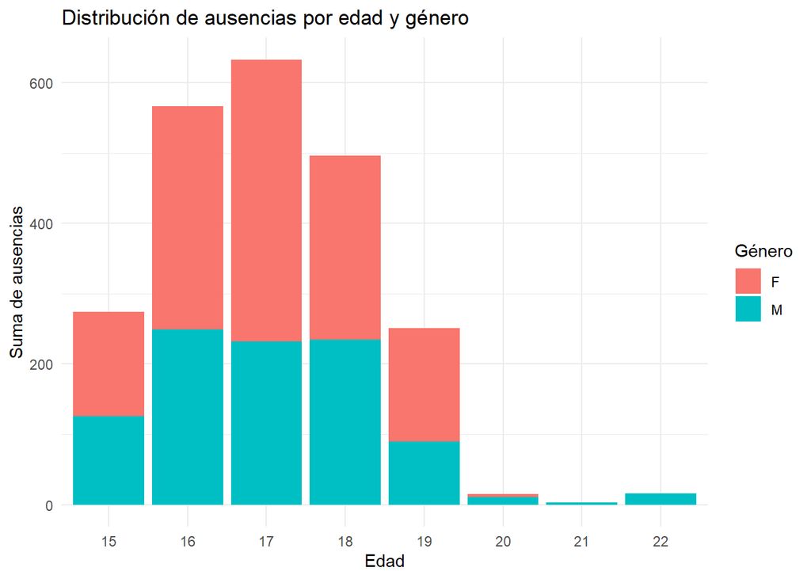

```r
tabla_pivote1_long <- tidyr::pivot_longer(tabla_pivote1, cols = -sex, names_to = "age", values_to = "absences_sum")

# Graficar el gráfico de barras apiladas
ggplot(tabla_pivote1_long, aes(x = age, y = absences_sum, fill = sex)) +
  geom_bar(stat = "identity", position = "stack") +
  labs(title = "Distribución de ausencias por edad y género",
       x = "Edad",
       y = "Suma de ausencias",
       fill = "Género") +
  theme_minimal()
```

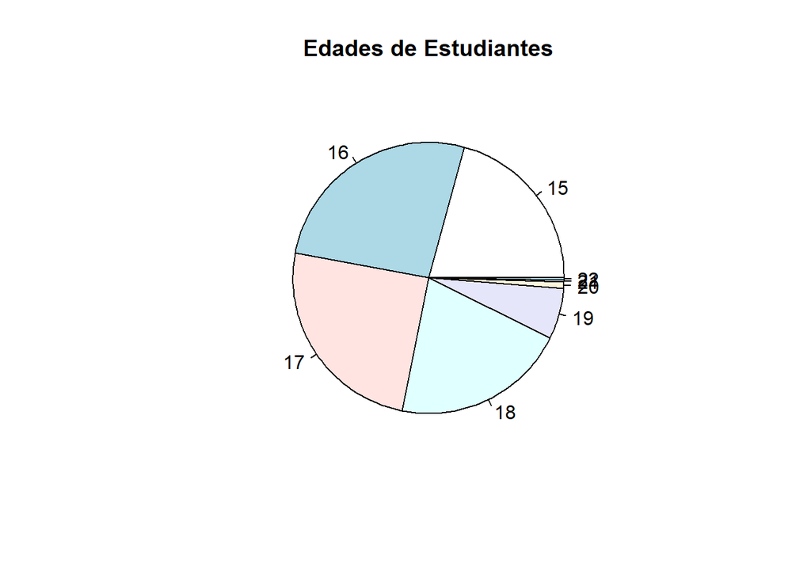

```r
pie(table(df1$age),main = "Edades de Estudiantes")
```

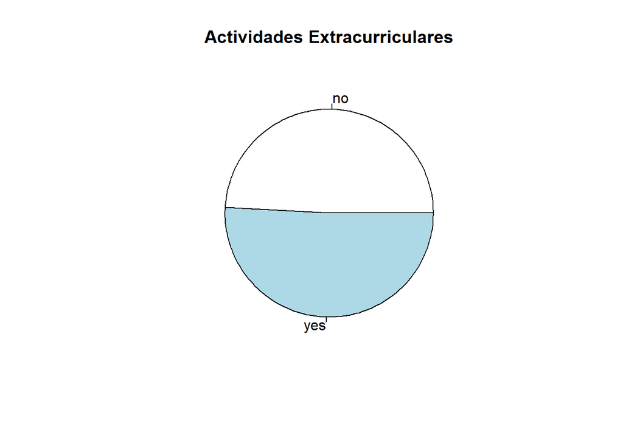

```r
pie(table(df1$activities),main = "Actividades Extracurriculares")
```

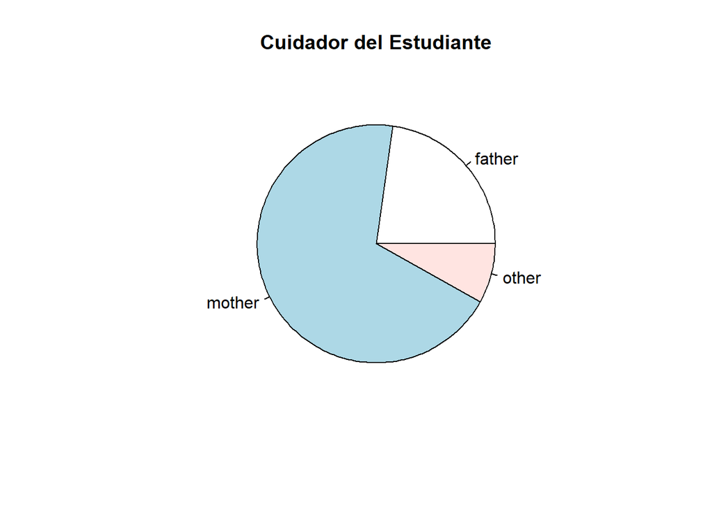

```r
pie(table(df1$guardian),main = "Cuidador del Estudiante")
```

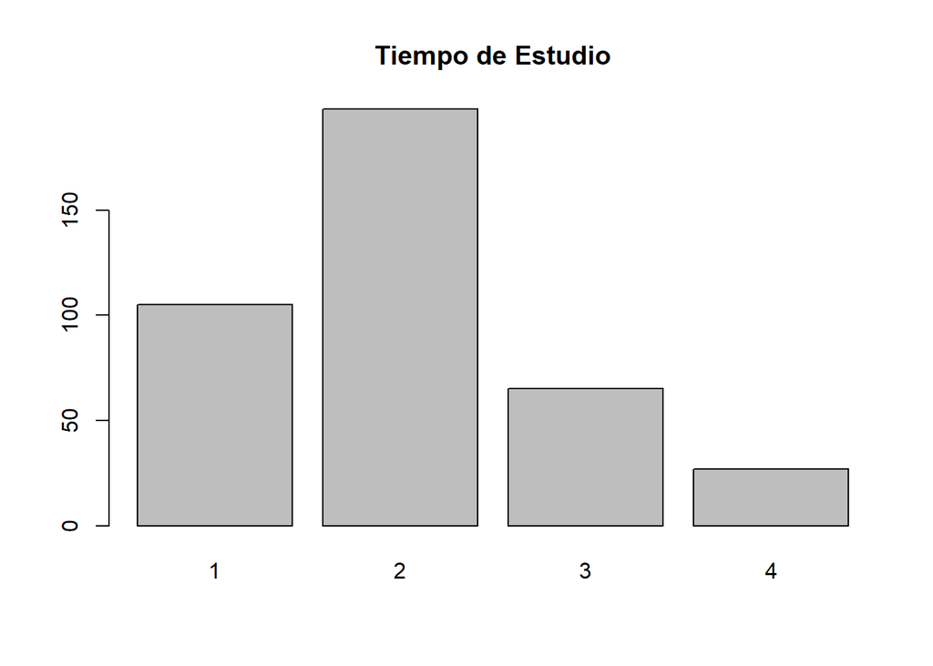

```r
barplot(table(df1$studytime),main = "Tiempo de Estudio")
```

**Tiempo de estudio**

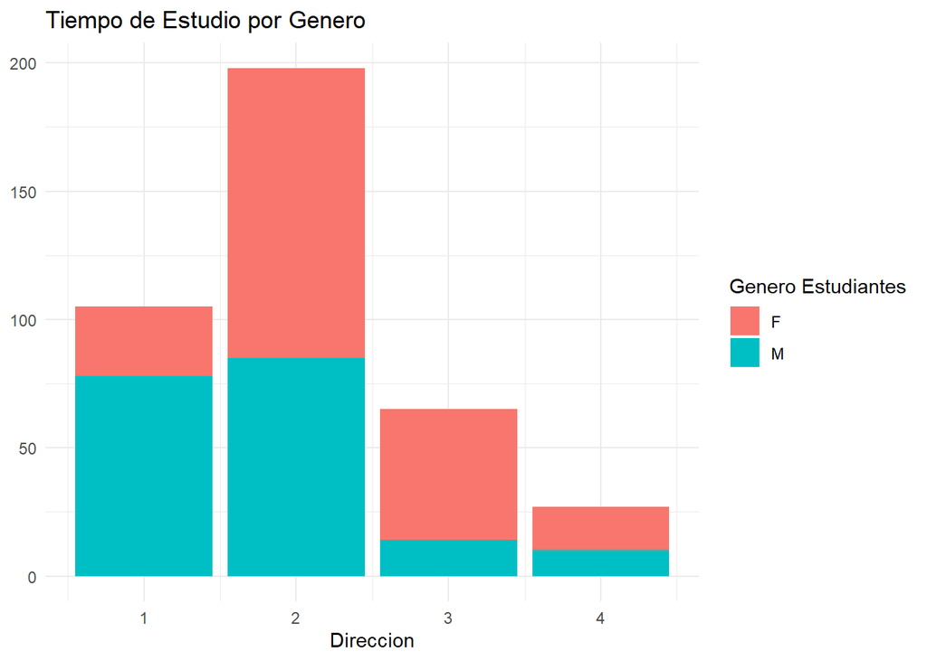

```r
df1 %>%
  ggplot() +
  geom_bar(aes(x = studytime, fill = sex)) +
  xlab("Direccion") +
  ylab(NULL) +
  labs(fill = "Genero Estudiantes") +
  labs(title = "Tiempo de Estudio por Genero") +
  theme_minimal()
```

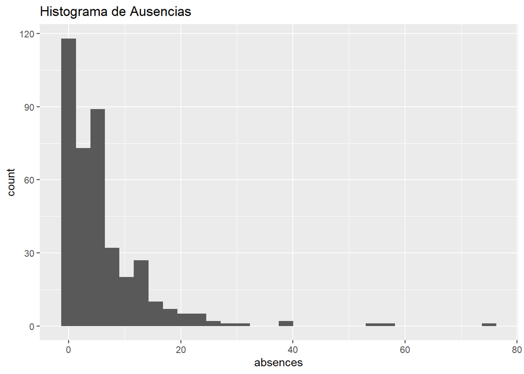

```r
ggplot(df1, aes(x = absences)) +
  geom_histogram() +
  labs(title = "Histograma de Ausencias")
```

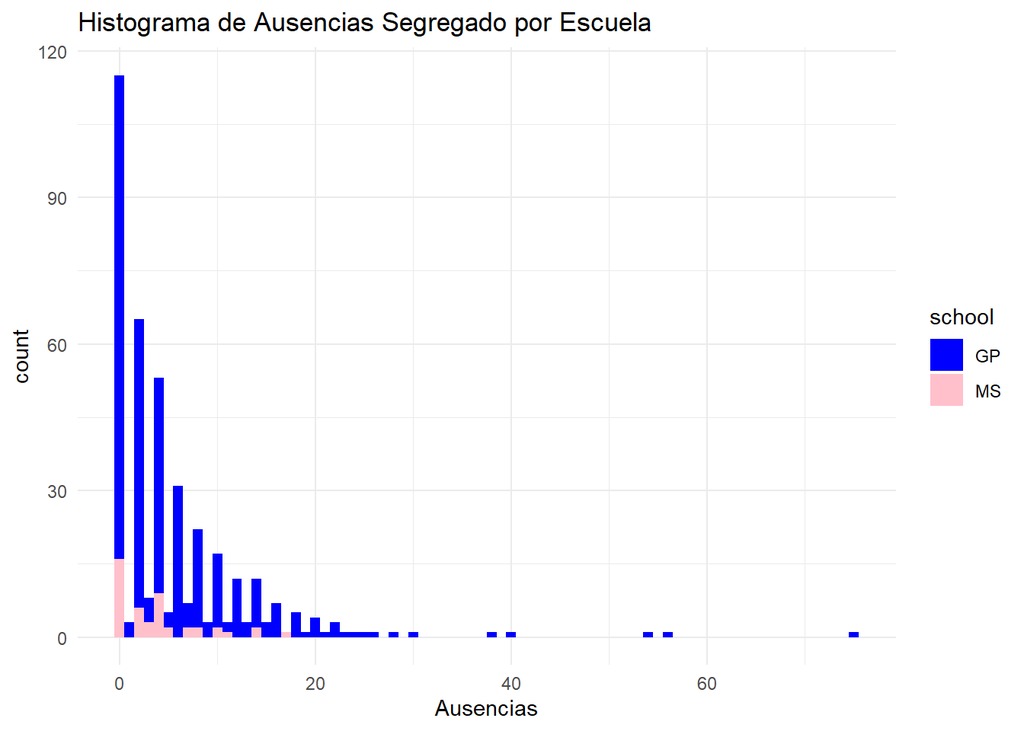

```r
ggplot(df1, aes(x = absences, fill = school)) +
  geom_histogram(position = "stack", binwidth = 1) +
  labs(title = "Histograma de Ausencias Segregado por Escuela", x = "Ausencias") +
  scale_fill_manual(values = c("blue", "pink")) +
  theme_minimal()
```

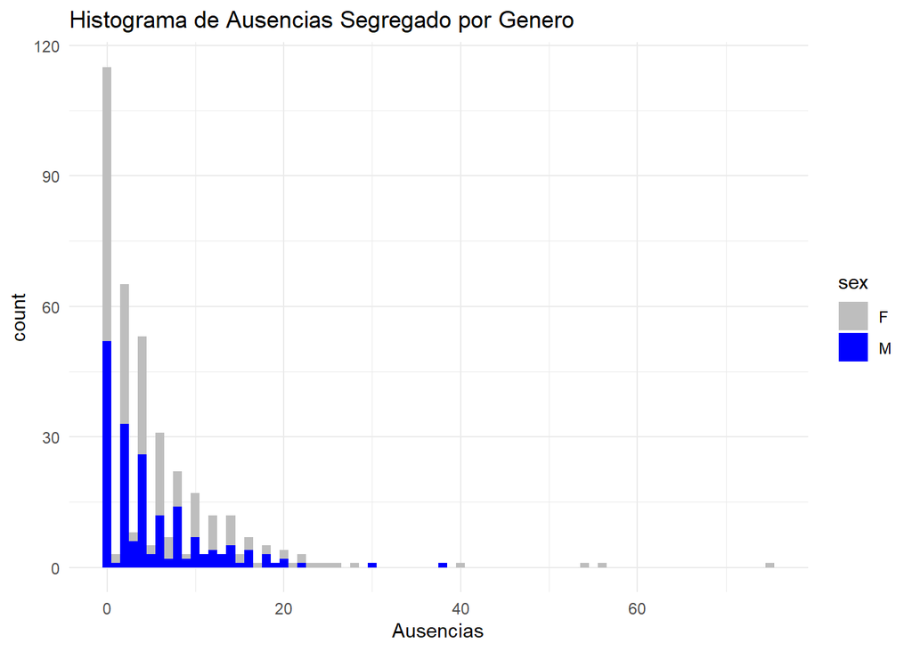

```r
ggplot(df1, aes(x = absences, fill = sex)) +
  geom_histogram(position = "stack", binwidth = 1) +
  labs(title = "Histograma de Ausencias Segregado por Genero", x = "Ausencias") +
  scale_fill_manual(values = c("gray", "blue")) +
  theme_minimal()
```

#### PASO TRES

** Ahora es momento de decidir si las preconclusiones son ciertas o no. Apoyarse en la estadística inferencial y del diseño de experimentos.**

```r
## Un paso que se debe agregar para proceder, es pasar unas variables
## de tipo categorica a tipo numerico, para proceder con los
## metodos estadisticos
```

```r
df2 <- df1 %>% mutate(school = recode(school, "GP" = 0, "MS" = 1))
```

```r
df3 <- df2 %>% mutate(sex = recode(sex, "M" = 0, "F" = 1))
```

```r
str(df3)
```

```
## 'data.frame':    395 obs. of  33 variables:
##  $ school    : num  0 0 0 0 0 0 0 0 0 0 ...
##  $ sex       : num  1 1 1 1 1 0 0 1 0 0 ...
##  $ age       : int  18 17 15 15 16 16 16 17 15 15 ...
##  $ address   : Factor w/ 2 levels "R","U": 2 2 2 2 2 2 2 2 2 2 ...
##  $ famsize   : Factor w/ 2 levels "GT3","LE3": 1 1 2 1 1 2 2 1 2 1 ...
##  $ Pstatus   : Factor w/ 2 levels "A","T": 1 2 2 2 2 2 2 1 1 2 ...
##  $ Medu      : int  4 1 1 4 3 4 2 4 3 3 ...
##  $ Fedu      : int  4 1 1 2 3 3 2 4 2 4 ...
##  $ Mjob      : Factor w/ 5 levels "at_home","health",..: 1 1 1 2 3 4 3 3 4 3 ...
##  $ Fjob      : Factor w/ 5 levels "at_home","health",..: 5 3 3 4 3 3 3 5 3 3 ...
##  $ reason    : Factor w/ 4 levels "course","home",..: 1 1 3 2 2 4 2 2 2 2 ...
##  $ guardian  : Factor w/ 3 levels "father","mother",..: 2 1 2 2 1 2 2 2 2 2 ...
##  $ traveltime: int  2 1 1 1 1 1 1 2 1 1 ...
##  $ studytime : int  2 2 2 3 2 2 2 2 2 2 ...
```

[output cut: 19 more lines]

```r
summary(df3)
```

```
##      school            sex              age       address famsize   Pstatus
##  Min.   :0.0000   Min.   :0.0000   Min.   :15.0   R: 88   GT3:281   A: 41
##  1st Qu.:0.0000   1st Qu.:0.0000   1st Qu.:16.0   U:307   LE3:114   T:354
##  Median :0.0000   Median :1.0000   Median :17.0
##  Mean   :0.1165   Mean   :0.5266   Mean   :16.7
##  3rd Qu.:0.0000   3rd Qu.:1.0000   3rd Qu.:18.0
##  Max.   :1.0000   Max.   :1.0000   Max.   :22.0
##       Medu            Fedu             Mjob           Fjob            reason
##  Min.   :0.000   Min.   :0.000   at_home : 59   at_home : 20   course    :145
##  1st Qu.:2.000   1st Qu.:2.000   health  : 34   health  : 18   home      :109
##  Median :3.000   Median :2.000   other   :141   other   :217   other     : 36
##  Mean   :2.749   Mean   :2.522   services:103   services:111   reputation:105
##  3rd Qu.:4.000   3rd Qu.:3.000   teacher : 58   teacher : 29
##  Max.   :4.000   Max.   :4.000
##    guardian     traveltime      studytime        failures      schoolsup
##  father: 90   Min.   :1.000   Min.   :1.000   Min.   :0.0000   no :344
##  mother:273   1st Qu.:1.000   1st Qu.:1.000   1st Qu.:0.0000   yes: 51
##  other : 32   Median :1.000   Median :2.000   Median :0.0000
##               Mean   :1.448   Mean   :2.035   Mean   :0.3342
##               3rd Qu.:2.000   3rd Qu.:2.000   3rd Qu.:0.0000
##               Max.   :4.000   Max.   :4.000   Max.   :3.0000
##  famsup     paid     activities nursery   higher    internet  romantic
##  no :153   no :214   no :194    no : 81   no : 20   no : 66   no :263
##  yes:242   yes:181   yes:201    yes:314   yes:375   yes:329   yes:132
##
##
##
##
##      famrel         freetime         goout            Dalc
##  Min.   :1.000   Min.   :1.000   Min.   :1.000   Min.   :1.000
##  1st Qu.:4.000   1st Qu.:3.000   1st Qu.:2.000   1st Qu.:1.000
##  Median :4.000   Median :3.000   Median :3.000   Median :1.000
##  Mean   :3.944   Mean   :3.235   Mean   :3.109   Mean   :1.481
##  3rd Qu.:5.000   3rd Qu.:4.000   3rd Qu.:4.000   3rd Qu.:2.000
##  Max.   :5.000   Max.   :5.000   Max.   :5.000   Max.   :5.000
##       Walc           health         absences            G1
##  Min.   :1.000   Min.   :1.000   Min.   : 0.000   Min.   : 3.00
##  1st Qu.:1.000   1st Qu.:3.000   1st Qu.: 0.000   1st Qu.: 8.00
##  Median :2.000   Median :4.000   Median : 4.000   Median :11.00
##  Mean   :2.291   Mean   :3.554   Mean   : 5.709   Mean   :10.91
##  3rd Qu.:3.000   3rd Qu.:5.000   3rd Qu.: 8.000   3rd Qu.:13.00
##  Max.   :5.000   Max.   :5.000   Max.   :75.000   Max.   :19.00
##        G2              G3
##  Min.   : 0.00   Min.   : 0.00
##  1st Qu.: 9.00   1st Qu.: 8.00
##  Median :11.00   Median :11.00
##  Mean   :10.71   Mean   :10.42
##  3rd Qu.:13.00   3rd Qu.:14.00
##  Max.   :19.00   Max.   :20.00
```

**3.1. Encontrar las técnicas más apropiadas para corroborar las preconclusiones con la ayuda de un mapa.**

Vamos a realizar un grafico de correlacion, encontrar alguna insidencia entre algunas carateristicas.

Ademas se procede a realizar calculo de intervalos de confianza.

**3.2. Diseñar la metodología de análisis.**

Tomar el dataset y revisar las variables, aquellas que se requieren transformar se les aplica una tecnica de **Feature engineering**, se procede a buscar las relaciones entre variables, buscar o calcular los intervalos de confianza.

**Feature engineering** Ademas de los resultados previamente vistos, se procede a realizar una tecnica de feature engineering, en la que se va agregar una columna denoinada target, la cual indica si el estudiante pasa o no pasa el grado o materia. En este caso vamos a tener una un Faul o Success.

Segun parte de las indicaciones del dataset si estudiante logra una nota final de mayr igual a 10 entonces “pasa” el grado o materia, de lo contrario pierde el “fail”.

```r
# Agregar una nueva columna llamada 'resultado' basada en la columna 'G3'
df1 <- df1 %>%
        mutate(resultado = ifelse(G3 < 10, "fail", "success"))

### Se muestra el resultado del cambio realizado
colnames(df1)
```

```
##  [1] "school"     "sex"        "age"        "address"    "famsize"
##  [6] "Pstatus"    "Medu"       "Fedu"       "Mjob"       "Fjob"
## [11] "reason"     "guardian"   "traveltime" "studytime"  "failures"
## [16] "schoolsup"  "famsup"     "paid"       "activities" "nursery"
## [21] "higher"     "internet"   "romantic"   "famrel"     "freetime"
## [26] "goout"      "Dalc"       "Walc"       "health"     "absences"
## [31] "G1"         "G2"         "G3"         "resultado"
```

```r
head(df1$resultado)
```

```
## [1] "fail"    "fail"    "success" "success" "success" "success"
```

```r
## se procede a agregar la columna target que se alimenta de la columa Resultado
df1 <- df1 %>%
  mutate(target = ifelse(resultado == "fail", 0, 1))


### Se muestra el resultado del cambio realizado
colnames(df1)
```

```
##  [1] "school"     "sex"        "age"        "address"    "famsize"
##  [6] "Pstatus"    "Medu"       "Fedu"       "Mjob"       "Fjob"
## [11] "reason"     "guardian"   "traveltime" "studytime"  "failures"
## [16] "schoolsup"  "famsup"     "paid"       "activities" "nursery"
## [21] "higher"     "internet"   "romantic"   "famrel"     "freetime"
## [26] "goout"      "Dalc"       "Walc"       "health"     "absences"
## [31] "G1"         "G2"         "G3"         "resultado"  "target"
```

```r
head(df1$target)
```

```
## [1] 0 0 1 1 1 1
```

```r
df2 <- df1 %>% mutate(school = recode(school, "GP" = 0, "MS" = 1))
df3 <- df2 %>% mutate(sex = recode(sex, "M" = 0, "F" = 1))
```

**Muestra las nuevas columnas**

```r
colnames(df3)
```

```
##  [1] "school"     "sex"        "age"        "address"    "famsize"
##  [6] "Pstatus"    "Medu"       "Fedu"       "Mjob"       "Fjob"
## [11] "reason"     "guardian"   "traveltime" "studytime"  "failures"
## [16] "schoolsup"  "famsup"     "paid"       "activities" "nursery"
## [21] "higher"     "internet"   "romantic"   "famrel"     "freetime"
## [26] "goout"      "Dalc"       "Walc"       "health"     "absences"
## [31] "G1"         "G2"         "G3"         "resultado"  "target"
```

**3.3. Aplicar esta metodología.**

**Se muestra un grafico en el que se hace una relacion entre variables**

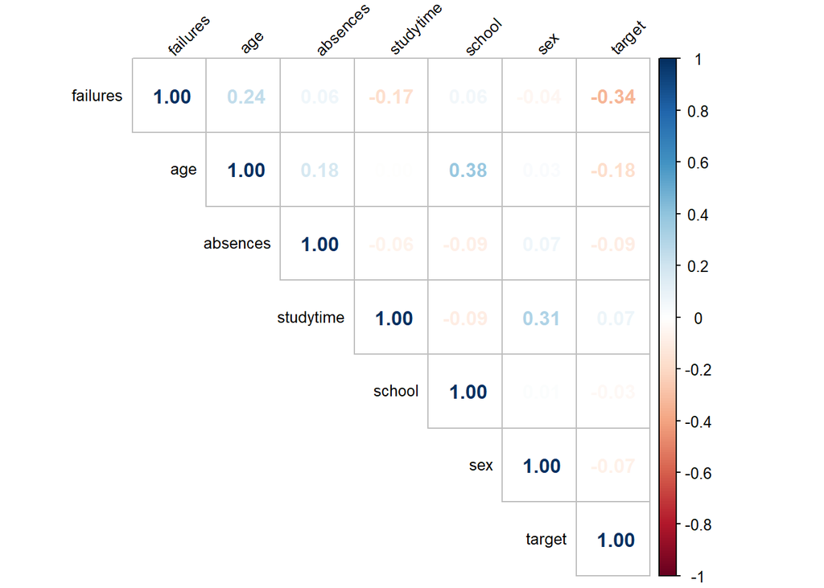

```r
df3 %>%
  select(failures, age, absences,studytime, school, sex,target) %>%
  cor() %>%
  corrplot(method = "number",
           type = "upper",
           tl.cex = 0.8,
           tl.srt = 45,
           tl.col = "black")
```

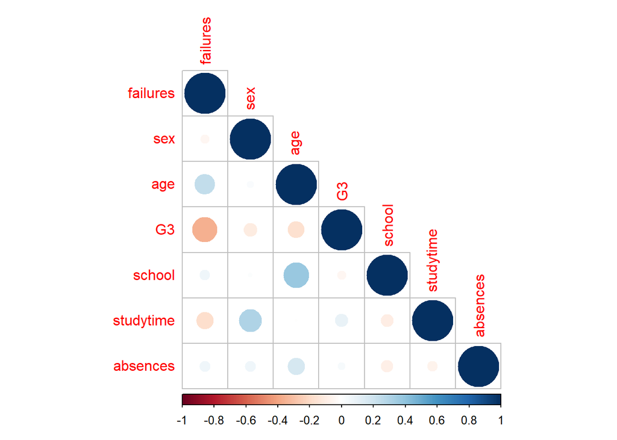

```r
require(corrplot)
# Subconjunto y selecciona las columnas específicas failures, age, absences,studytime, school, sex,target
subset_df <- df3[, c("failures","sex", "age", "G3", "school", "studytime", "absences")]

# Calcula la matriz de correlación y redondea los valores
correlation_matrix <- cor(subset_df)
correlation_matrix <- round(correlation_matrix, digits = 3)

# Visualiza la matriz de correlación
corrplot(correlation_matrix, type = "lower")
```

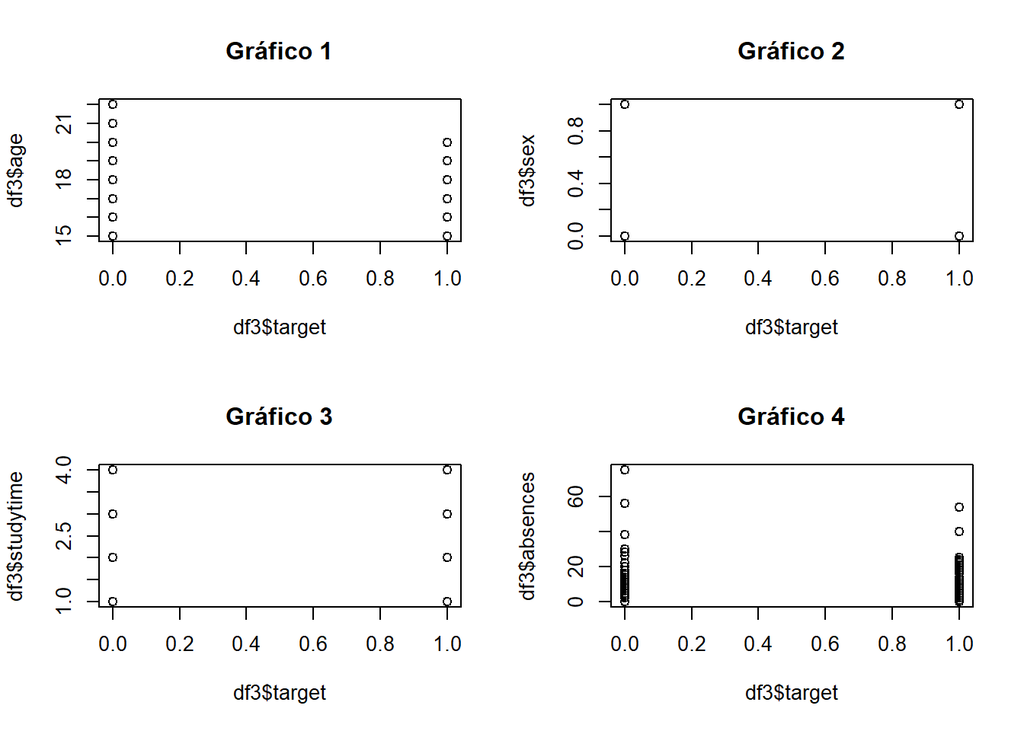

```r
par(mfrow = c(2, 2))  # Divide el área de trazado en un arreglo de 2x2 para 4 gráficos

# Gráfico 1
plot(df3$target, df3$age, main = "Gráfico 1")

# Gráfico 2
plot(df3$target, df3$sex, main = "Gráfico 2")

# Gráfico 3
plot(df3$target, df3$studytime, main = "Gráfico 3")

# Gráfico 4
plot(df3$target, df3$absences, main = "Gráfico 4")
```

```r
 modelo_genero <- lm(target~sex, data = df3)
summary(modelo_genero)
```

```
##
## Call:
## lm(formula = target ~ sex, data = df3)
##
## Residuals:
##     Min      1Q  Median      3Q     Max
## -0.7059 -0.6394  0.2941  0.3606  0.3606
##
## Coefficients:
##             Estimate Std. Error t value Pr(>|t|)
## (Intercept)  0.70588    0.03436  20.542   <2e-16 ***
## sex         -0.06646    0.04735  -1.403    0.161
## ---
## Signif. codes:  0 '***' 0.001 '**' 0.01 '*' 0.05 '.' 0.1 ' ' 1
##
## Residual standard error: 0.4699 on 393 degrees of freedom
## Multiple R-squared:  0.004987,   Adjusted R-squared:  0.002455
## F-statistic:  1.97 on 1 and 393 DF,  p-value: 0.1613
```

```r
 modelo_genero <- lm(target~studytime, data = df3)
summary(modelo_genero)
```

```
##
## Call:
## lm(formula = target ~ studytime, data = df3)
##
## Residuals:
##     Min      1Q  Median      3Q     Max
## -0.7531 -0.6276  0.2888  0.3306  0.3724
##
## Coefficients:
##             Estimate Std. Error t value Pr(>|t|)
## (Intercept)  0.58575    0.06208   9.436   <2e-16 ***
## studytime    0.04183    0.02820   1.483    0.139
## ---
## Signif. codes:  0 '***' 0.001 '**' 0.01 '*' 0.05 '.' 0.1 ' ' 1
##
## Residual standard error: 0.4698 on 393 degrees of freedom
## Multiple R-squared:  0.005567,   Adjusted R-squared:  0.003037
## F-statistic:   2.2 on 1 and 393 DF,  p-value: 0.1388
```

```r
 modelo_genero <- lm(target~age, data = df3)
summary(modelo_genero)
```

```
##
## Call:
## lm(formula = target ~ age, data = df3)
##
## Residuals:
##     Min      1Q  Median      3Q     Max
## -0.7832 -0.5845  0.2830  0.3492  0.5480
##
## Coefficients:
##             Estimate Std. Error t value Pr(>|t|)
## (Intercept)  1.77678    0.30637    5.80 1.37e-08 ***
## age         -0.06624    0.01830   -3.62 0.000333 ***
## ---
## Signif. codes:  0 '***' 0.001 '**' 0.01 '*' 0.05 '.' 0.1 ' ' 1
##
## Residual standard error: 0.4634 on 393 degrees of freedom
## Multiple R-squared:  0.03227,    Adjusted R-squared:  0.02981
## F-statistic: 13.11 on 1 and 393 DF,  p-value: 0.0003329
```

```r
modelo_genero <- lm(G3~studytime, data = df3)
summary(modelo_genero)
```

```
##
## Call:
## lm(formula = G3 ~ studytime, data = df3)
##
## Residuals:
##      Min       1Q   Median       3Q      Max
## -11.4643  -1.8623   0.5357   3.0697   9.1377
##
## Coefficients:
##             Estimate Std. Error t value Pr(>|t|)
## (Intercept)   9.3283     0.6033  15.463   <2e-16 ***
## studytime     0.5340     0.2741   1.949   0.0521 .
## ---
## Signif. codes:  0 '***' 0.001 '**' 0.01 '*' 0.05 '.' 0.1 ' ' 1
##
## Residual standard error: 4.565 on 393 degrees of freedom
## Multiple R-squared:  0.009569,   Adjusted R-squared:  0.007049
## F-statistic: 3.797 on 1 and 393 DF,  p-value: 0.05206
```

```r
modelo_genero <- lm(G3~sex, data = df3)
summary(modelo_genero)
```

```
##
## Call:
## lm(formula = G3 ~ sex, data = df3)
##
## Residuals:
##      Min       1Q   Median       3Q      Max
## -10.9144  -1.9663   0.0856   3.0856   9.0856
##
## Coefficients:
##             Estimate Std. Error t value Pr(>|t|)
## (Intercept)  10.9144     0.3337  32.712   <2e-16 ***
## sex          -0.9481     0.4598  -2.062   0.0399 *
## ---
## Signif. codes:  0 '***' 0.001 '**' 0.01 '*' 0.05 '.' 0.1 ' ' 1
##
## Residual standard error: 4.563 on 393 degrees of freedom
## Multiple R-squared:  0.0107, Adjusted R-squared:  0.008186
## F-statistic: 4.252 on 1 and 393 DF,  p-value: 0.03987
```

```r
modelo_genero <- lm(G3~school, data = df3)
summary(modelo_genero)
```

```
##
## Call:
## lm(formula = G3 ~ school, data = df3)
##
## Residuals:
##     Min      1Q  Median      3Q     Max
## -10.490  -1.848   0.510   3.510   9.510
##
## Coefficients:
##             Estimate Std. Error t value Pr(>|t|)
## (Intercept)  10.4900     0.2453  42.764   <2e-16 ***
## school       -0.6421     0.7188  -0.893    0.372
## ---
## Signif. codes:  0 '***' 0.001 '**' 0.01 '*' 0.05 '.' 0.1 ' ' 1
##
## Residual standard error: 4.583 on 393 degrees of freedom
## Multiple R-squared:  0.002027,   Adjusted R-squared:  -0.0005128
## F-statistic: 0.798 on 1 and 393 DF,  p-value: 0.3722
```

```r
modelo_genero <- lm(G3~failures, data = df3)
summary(modelo_genero)
```

```
##
## Call:
## lm(formula = G3 ~ failures, data = df3)
##
## Residuals:
##      Min       1Q   Median       3Q      Max
## -11.1572  -2.1572  -0.1572   2.8428   9.0632
##
## Coefficients:
##             Estimate Std. Error t value Pr(>|t|)
## (Intercept)  11.1572     0.2361   47.26  < 2e-16 ***
## failures     -2.2204     0.2899   -7.66 1.47e-13 ***
## ---
## Signif. codes:  0 '***' 0.001 '**' 0.01 '*' 0.05 '.' 0.1 ' ' 1
##
## Residual standard error: 4.279 on 393 degrees of freedom
## Multiple R-squared:  0.1299, Adjusted R-squared:  0.1277
## F-statistic: 58.67 on 1 and 393 DF,  p-value: 1.466e-13
```

```r
round(cor(subset(df3, select = target), method = "pearson"), digits = 2)
```

```
##        target
## target      1
```

### Calculo de los Intervalos de Confianza

```r
## calculo de intervalo de confianza
t.test(df1$age, conf.level =0.95)$conf.int
```

```
## [1] 16.56998 16.82243
## attr(,"conf.level")
## [1] 0.95
```

```r
## Estamos seguros en un 95% que la edad de los estudiantes se ## encuentra entre 16.56 y 16.82
```

```r
## calculo de intervalo de confianza
t.test(df1$absences, conf.level =0.95)$conf.int
```

```
## [1] 4.917192 6.500530
## attr(,"conf.level")
## [1] 0.95
```

```r
## Estamos seguros en un 95% que la cantidad de ausencias de los ## estudiantes se encuentra entre 4.91  y 6.5
```

```r
## calculo de intervalo de confianza
t.test(df1$G3, conf.level =0.95)$conf.int
```

```
## [1]  9.961992 10.868388
## attr(,"conf.level")
## [1] 0.95
```

```r
## Estamos seguros en un 95% que los resultados  de los estudiantes se encuentra entre  9.96    y 10.86
```

```r
Detalle1 <- df1 %>%
  group_by(sex) %>%
  summarise(media_target = mean(G3))

# Mostrar los resultados
print(Detalle1)
```

```
## # A tibble: 2 × 2
##   sex   media_target
##   <fct>        <dbl>
## 1 F             9.97
## 2 M            10.9
```

```r
Detalle1 <- df1 %>%
  group_by(sex) %>%
  summarise(media_target = mean(G3))

# Mostrar los resultados
print(Detalle1)
```

```
## # A tibble: 2 × 2
##   sex   media_target
##   <fct>        <dbl>
## 1 F             9.97
## 2 M            10.9
```

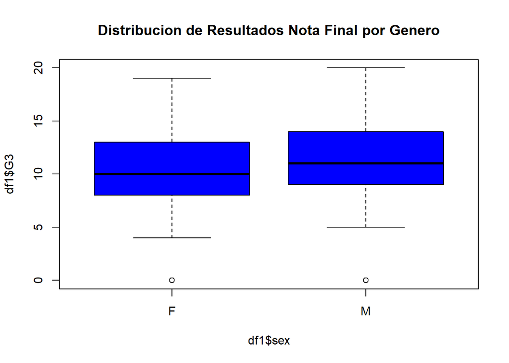

```r
boxplot(df1$G3 ~ df1$sex, col = "blue",
main = "Distribucion de Resultados Nota Final por Genero")
```

```r
qhpvt(df1, "sex", "G3", "n()")
```

[interactive chart not shown]

```r
qhpvt(df1, "sex", "target", "n()")
```

[interactive chart not shown]

#### **3.4. Resumir los resultados.**

Tenemos un dataset con una poblacion estudiantil de dos escuelas diferentes, ademas de otras caracteristicas como genero, edad, ausencias, materias perdidas, actividades extracurriculares, trabajo del padre y madre.

Tenemos una columna llamada G3 la cual representa el resultado final de la nota del estudiante, se le procedio aplicar tecnica de **Feature engineering**, para transformar los valores para obetener una columna con un resultado el cual es de tipo binario = fail(0) o success (1), esto facilita el manejo de los datos y permite crear relaciones.

Por medio del calculo de P-value se logra ver un valor de relevancia significativa p-value: 0.0003329, cuando relacionamos las variables entre la EDAD y la variable Target.

Tenemos una gran poblacion de estuadiantes provenientes de las zonas Urbanas.

La mayor poblacion de estudiantil de este caso de estudio se encuentra entre las edades de 15 a 17 años.

Cuando se realiza los Pvalues para la realacion de los Failures y la columna G3 (nota final), se muestra una relacion significativa. Por lo tanto tener o presentar altos Failures insiden sobre el resultado de G3 (la nota final del curso)

Tambien tenemos un resultado de p-value: 0.03987 para la relacion de Genero (sex) contra el resulta de G3, por lo que tal parece en este caso de estudio el sexo infiere sobre el resultado.

```r
 qhpvt(df1, "age", "absences", "n()")
```

[interactive chart not shown]

```r
 qhpvt(df1, "sex", "absences", "n()")
```

[interactive chart not shown]

```r
 qhpvt(df1, "school", "absences", "n()")
```

[interactive chart not shown]

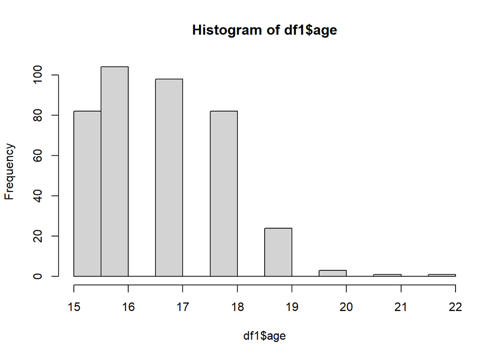

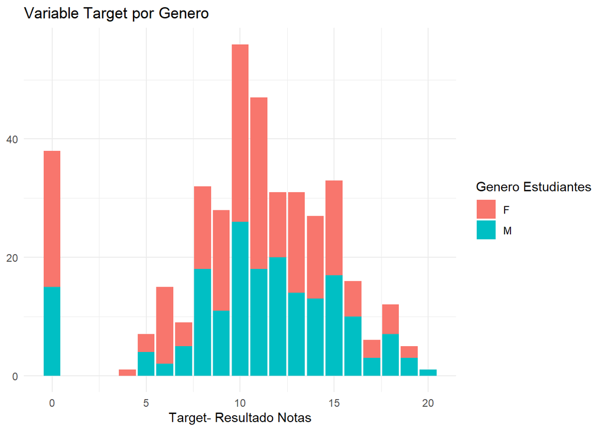

```r
df1 %>%
  ggplot() +
  geom_bar(aes(x = G3, fill = sex)) +
  xlab("Target- Resultado Notas") +
  ylab(NULL) +
  labs(fill = "Genero Estudiantes") +
  labs(title = "Variable Target por Genero") +
  theme_minimal()
```

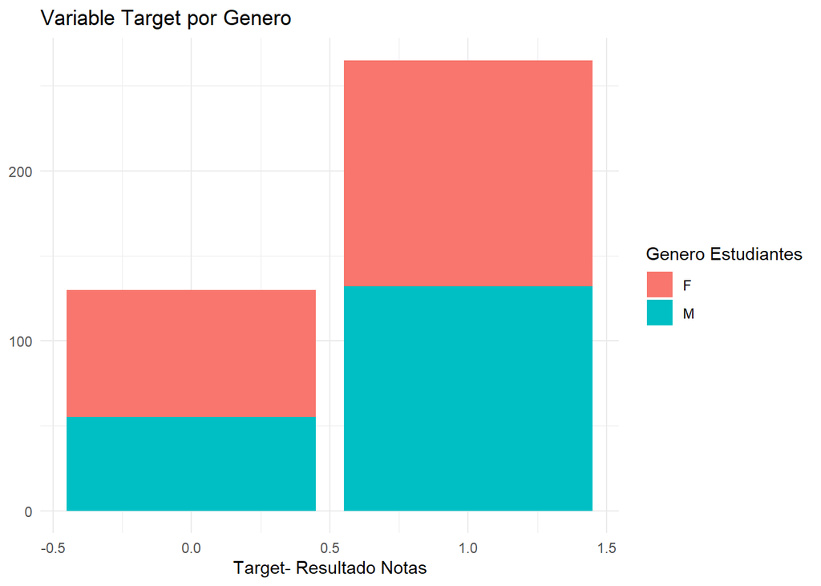

```r
df1 %>%
  ggplot() +
  geom_bar(aes(x = target, fill = sex)) +
  xlab("Target- Resultado Notas") +
  ylab(NULL) +
  labs(fill = "Genero Estudiantes") +
  labs(title = "Variable Target por Genero") +
  theme_minimal()
```

IMF Master en Data Science Curso: Estadistica para Ciencia de Datos Final_estadistica_IMF_AnalisisDatos Estudiante Richard Douglas Grijalba, Modalidad Virtual.

Costa Rica - Pura Vida